# EDS 222 Final Project

Elke Windschitll

2022-12-01

# Identifying key traits in Hawaiian fish to predict risk of extinction

According to the IUCN, “More than 41,000 species are threatened with extinction. That is still 28% of all assessed species.” (IUCN 2020). Wildlife scientists have been working to understand what ecological traits of vertebrates predict threat level, and what are common risk factors driving those threat level rates (Munstermann et al. 2022). This knowledge can help inform policies and practices with the goal to decrease threats of extinction of wildlife. In recent years, the waters surrounding the Hawaiian Islands have been exposed to climate and ecological changes due to mass coral bleaching events, El Nino events, and pollution. Here, I propose to investigate Hawaiian fish ecological traits – such as endemism, size, and reef-association – to predict their status on the IUCN red list. I will use data from the IUCN (IUCN 2020) and FishBase (Froese & Pauly 2022) and analyze by running logistic regression with a categorical binary outcome and 1-3 explanatory variables.

## Import data

I wrangled and combined data from RFishBase and the IUCN Red List in the R Script called fishbase.R. Here is the tidy data set.

```r
tidy_fish_data <- read.csv(file.path(datadir, "hi_tidy_fish_data.csv"))
head(tidy_fish_data)
```

```
##   X spec_code freq           genus_species length_cm weight     status
## 1 1         3    1 Oreochromis mossambicus      39.0   1130 introduced
## 2 2         6    1     Coryphaena hippurus     210.0  40000     native
## 3 3         7    1    Coryphaena equiselis     145.7     NA     native
## 4 4        10    1          Alectis indica     165.0  25000     native
## 5 5        40    1   Argyropelecus affinis       8.4     NA     native
## 6 6        46    1  Melanolagus bericoides      20.0     NA     native
##   current_presence         genus     species      importance.y price_categ
## 1          present   Oreochromis mossambicus highly commercial     unknown
## 2          present    Coryphaena    hippurus highly commercial        high
## 3          present    Coryphaena   equiselis  minor commercial     unknown
## 4          present       Alectis      indica        commercial      medium
## 5          present Argyropelecus     affinis    of no interest     unknown
## 6          present   Melanolagus  bericoides    of no interest     unknown
##   coral_reefs                  feeding_type schooling category
## 1           0         browsing on substrate         0       VU
## 2           1 hunting macrofauna (predator)         0       LC
## 3           0 hunting macrofauna (predator)         0       LC
## 4           1 hunting macrofauna (predator)         0       LC
## 5           0    selective plankton feeding         0       LC
## 6           0    selective plankton feeding         0       LC
##         main_common_name is_of_concern reef_associated is_endemic
## 1     Mozambique Tilapia             1              no         no
## 2     Common Dolphinfish             0             yes         no
## 3    Pompano Dolphinfish             0              no         no
## 4      Indian Threadfish             0             yes         no
## 5   Pacific Hatchet Fish             0              no         no
## 6 Bigscale Deepsea Smelt             0              no         no
```

## Explore data columns of interest

1. IUCN Red List status

```r
table(tidy_fish_data$is_of_concern)
```

```
##
##   0   1
## 618  32
```

**Are these numbers poor for analysis?**

2. Fish length

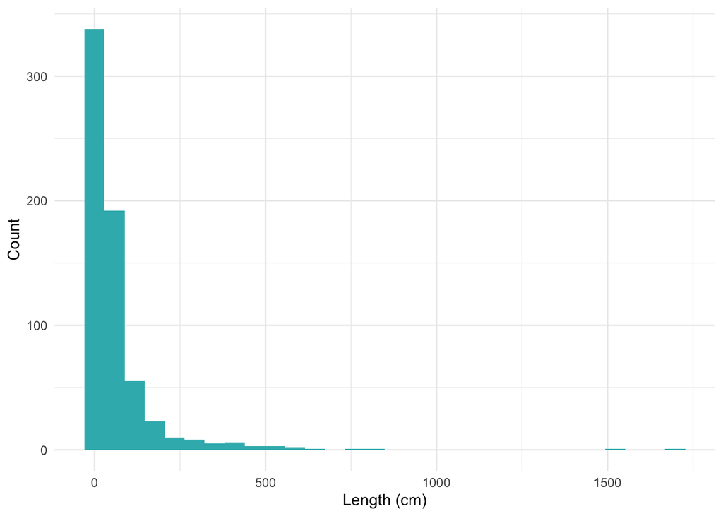

```r
ggplot(tidy_fish_data, aes(x = length_cm)) +
  geom_histogram(fill = "#38b6ba") +
  xlab("Length (cm)") +
  ylab("Count") +
  theme_minimal()
```

3. Reef-Association

```r
table(tidy_fish_data$reef_associated)
```

```
##
##  no yes
## 340 310
```

4. Endemic

```r
table(tidy_fish_data$is_endemic)
```

```
##
##  no yes
## 639  11
```

**Are these numbers poor for analysis?**

## Analysis

### Length

$$\operatorname{logit}(p)=\log
\left(\frac{p}{1-p}\right)=\beta_0+\beta_1 (Length) +\varepsilon$$

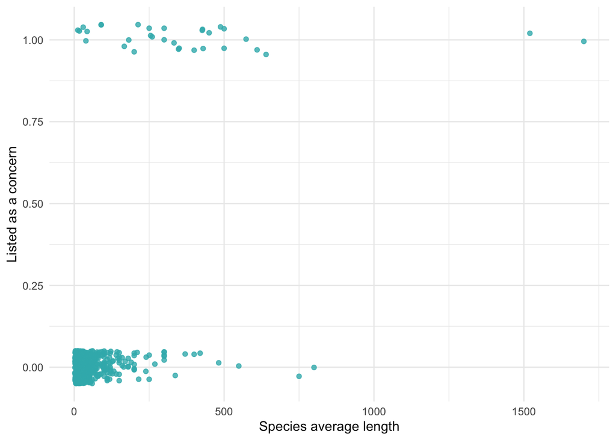

```r
# Graph length vs is of concern
gg_len <- ggplot(data = tidy_fish_data, aes(x = length_cm, y = is_of_concern)) +
  geom_jitter(width = 0, height = 0.05, alpha = 0.8, col = "#38b6ba") +
  labs(x = "Species average length", y = "Listed as a concern") +
  theme_minimal()
gg_len
```

```r
# Log regression length
mod_length <- glm(is_of_concern ~ length_cm,
                 data = tidy_fish_data,
                 family = "binomial")
summary(mod_length)
```

```
##
## Call:
## glm(formula = is_of_concern ~ length_cm, family = "binomial",
##     data = tidy_fish_data)
##
## Deviance Residuals:
##     Min       1Q   Median       3Q      Max
## -2.9017  -0.2072  -0.1805  -0.1685   2.9161
##
## Coefficients:
##              Estimate Std. Error z value Pr(>|z|)
## (Intercept) -4.365788   0.327099 -13.347  < 2e-16 ***
## length_cm    0.010701   0.001369   7.816 5.47e-15 ***
## ---
## Signif. codes:  0 '***' 0.001 '**' 0.01 '*' 0.05 '.' 0.1 ' ' 1
##
## (Dispersion parameter for binomial family taken to be 1)
##
##     Null deviance: 255.12  on 649  degrees of freedom
## Residual deviance: 162.30  on 648  degrees of freedom
## AIC: 166.3
##
## Number of Fisher Scoring iterations: 6
```

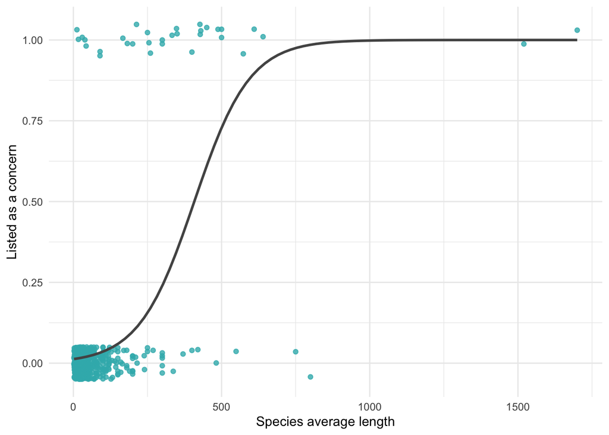

```r
# Plot with regression
len_data_space <- gg_len +
  geom_smooth(method = "glm",
              se = FALSE, color = "#545454",
              method.args = list(family = "binomial"))
len_data_space
```

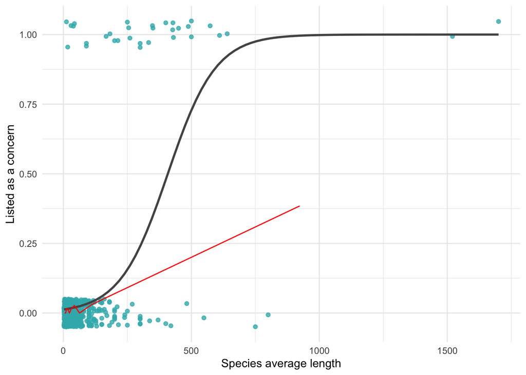

```r
# Make bins
len_breaks <- tidy_fish_data %>%
  pull(length_cm) %>%
  quantile(probs = 0:10/10)

len_binned_space <- len_data_space +
  stat_summary_bin(
    fun = "mean", color = "red",
    geom = "line", breaks = len_breaks
  )

len_binned_space
```

**What exactly did this do?**

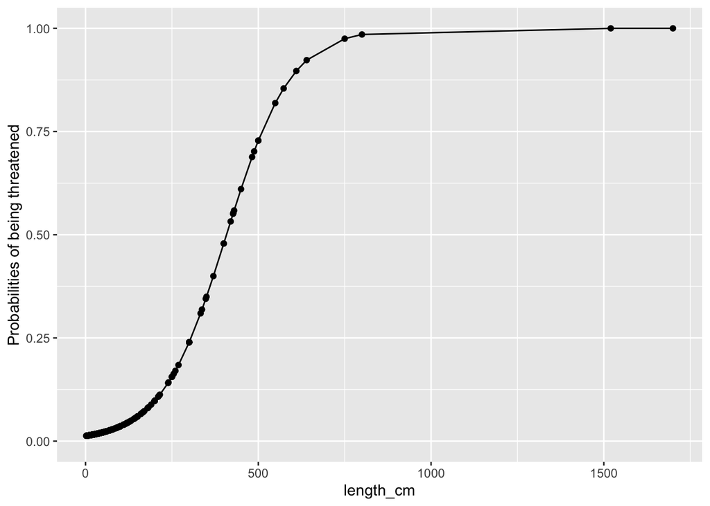

```r
# Compute fitted probabilities, then graph
length_plus <- mod_length %>%
  augment(type.predict = "response") %>%
  mutate(y_hat = .fitted)
ggplot(length_plus, aes(x = length_cm, y = y_hat)) +
  geom_point() +
  geom_line() +
  scale_y_continuous("Probabilities of being threatened",
                     limits = c(0,1))
```

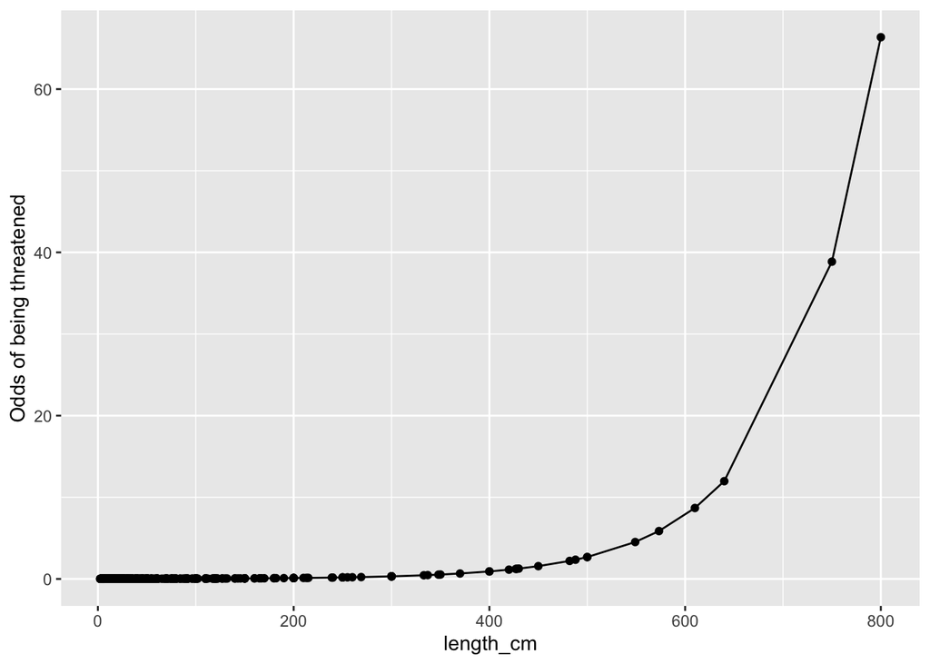

```r
# Compute odds scale and graph it
length_plus <- length_plus %>%
mutate(odds_hat = y_hat / (1 - y_hat)) %>%
  filter(length_cm <= 1000) # remove outliers for graphing
ggplot(length_plus, aes(x = length_cm, y = odds_hat)) +
  geom_point() +
  geom_line() +
  scale_y_continuous("Odds of being threatened")
```

```r
# Pull B1
len_b1 <- mod_length$coefficients[2]
len_odds_ratio <- exp(len_b1)
print(paste0("The model suggests that each additional cm in length is associated with a ",
             round(len_odds_ratio, 1), "% increase in the odds of being threatened"))
```

```
## [1] "The model suggests that each additional cm in length is associated with a 1% increase in the odds of being threatened"
```

**Okay, the model suggests this, but how can I determine the significance, confidence of this?**

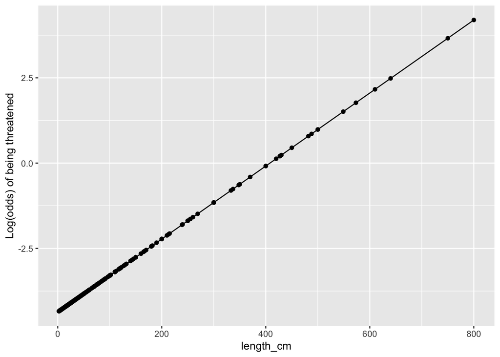

```r
# Compute log-odds and graph it
length_plus <- length_plus %>%
  mutate(log_odds_hat = log(odds_hat))
ggplot(length_plus, aes(x = length_cm, y = log_odds_hat)) +
  geom_point() +
  geom_line() +
  scale_y_continuous("Log(odds) of being threatened")
```

```r
# Create confusion matrix to see how well the model performed
length_plus <- augment(mod_length, type.predict = "response") %>%
  mutate(threatened_hat = round(.fitted)) %>%
  select(is_of_concern, length_cm, .fitted, threatened_hat)
l_tab <- length_plus %>%
  select(is_of_concern, threatened_hat) %>%
  table()
l_tab
```

```
##              threatened_hat
## is_of_concern   0   1
##             0 613   5
##             1  20  12
```

```r
acc <- (l_tab[1,1] + l_tab[2,2]) / nrow(length_plus) * 100
print(paste0("The accuracy of this model was ", round(acc), "%"))
```

```
## [1] "The accuracy of this model was 96%"
```

**BUT it seems to be more accurate in predicting species that are not actually of concern. Species that are actually threatened have poorer prediction rates… how important is this? And again, how do I measure confidence in this statement?**

### Reef-Associated

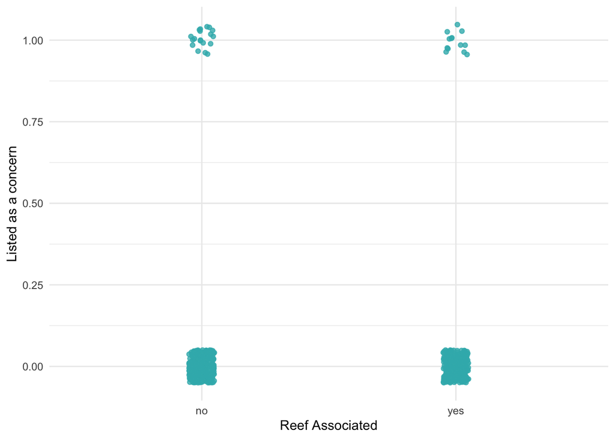

```r
# Plot reef associated vs is of concern
gg_reef <- ggplot(data = tidy_fish_data, aes(x = reef_associated, y = is_of_concern)) +
  geom_jitter(width = 0.05, height = 0.05, alpha = 0.8, col = "#38b6ba") +
  labs(x = "Reef Associated", y = "Listed as a concern") +
  theme_minimal()
gg_reef
```

```r
# Run a t.test
reef_test <- t.test(is_of_concern ~ reef_associated, data = tidy_fish_data)

# Log regression reefs -- does this even make sense to do?
mod_reef <- glm(is_of_concern ~ reef_associated,
                data = tidy_fish_data,
                family = "binomial")
summary(mod_reef)
```

```
##
## Call:
## glm(formula = is_of_concern ~ reef_associated, family = "binomial",
##     data = tidy_fish_data)
##
## Deviance Residuals:
##     Min       1Q   Median       3Q      Max
## -0.3391  -0.3391  -0.2927  -0.2927   2.5186
##
## Coefficients:
##                    Estimate Std. Error z value Pr(>|z|)
## (Intercept)         -2.8270     0.2361 -11.974   <2e-16 ***
## reef_associatedyes  -0.3018     0.3688  -0.818    0.413
## ---
## Signif. codes:  0 '***' 0.001 '**' 0.01 '*' 0.05 '.' 0.1 ' ' 1
##
## (Dispersion parameter for binomial family taken to be 1)
##
##     Null deviance: 255.12  on 649  degrees of freedom
## Residual deviance: 254.44  on 648  degrees of freedom
## AIC: 258.44
##
## Number of Fisher Scoring iterations: 5
```

**How do I interpret this coefficient? Or does it not make sense to run a regression of both a binary independent and binary dependent variable? This is why I also ran the t.test. Also, what is the best workflow here? If I ran the t.test and see that reef-association is insignificant, does it make any sense to add it to my model? I did for the experience of adding things to a model. Or would I have been fine without the t.test and proceeding below and discovering nothing significant there?**

$$\operatorname{logit}(p)=\log
\left(\frac{p}{1-p}\right)=\beta_0+\beta_1 (Length) + \beta_2 (Reef)
+\varepsilon$$

```r
# Add reef association to the model
len_reef_mod <- glm(is_of_concern ~ length_cm + reef_associated,
                    data = tidy_fish_data,
                    family = "binomial")
summary(len_reef_mod)
```

```
##
## Call:
## glm(formula = is_of_concern ~ length_cm + reef_associated, family = "binomial",
##     data = tidy_fish_data)
##
## Deviance Residuals:
##     Min       1Q   Median       3Q      Max
## -2.9034  -0.2071  -0.1805  -0.1685   2.9123
##
## Coefficients:
##                     Estimate Std. Error z value Pr(>|z|)
## (Intercept)        -4.354712   0.402029 -10.832  < 2e-16 ***
## length_cm           0.010693   0.001379   7.755 8.83e-15 ***
## reef_associatedyes -0.021704   0.460834  -0.047    0.962
## ---
## Signif. codes:  0 '***' 0.001 '**' 0.01 '*' 0.05 '.' 0.1 ' ' 1
##
## (Dispersion parameter for binomial family taken to be 1)
##
##     Null deviance: 255.12  on 649  degrees of freedom
## Residual deviance: 162.30  on 647  degrees of freedom
## AIC: 168.3
##
## Number of Fisher Scoring iterations: 6
```

```r
print(paste0("Fish that are reef associated see their odds of being threatened decrease by a factor of ", -round(len_reef_mod$coefficients[3], 2), " after controlling for length"))
```

```
## [1] "Fish that are reef associated see their odds of being threatened decrease by a factor of 0.02 after controlling for length"
```

```r
# Create confusion matrix to see how well the model performed
length_reef_plus <- augment(len_reef_mod, type.predict = "response") %>%
  mutate(threatened_hat = round(.fitted)) %>%
  select(is_of_concern, length_cm, reef_associated, .fitted, threatened_hat)
l_r_tab <- length_reef_plus %>%
  select(is_of_concern, threatened_hat) %>%
  table()
l_r_tab # Adding reef did nothing
```

```
##              threatened_hat
## is_of_concern   0   1
##             0 613   5
##             1  20  12
```

**As I can see here, adding reef-association did not seem to change the model. Where in my len_reef_mod output can I evaluate significance?**

### Endemism

**Endemism is essentially the same as reef-association, with some slight differences**

$$\operatorname{logit}(p)=\log
\left(\frac{p}{1-p}\right)=\beta_0+\beta_1 (Length) + \beta_2 (Endemic)
+\varepsilon$$

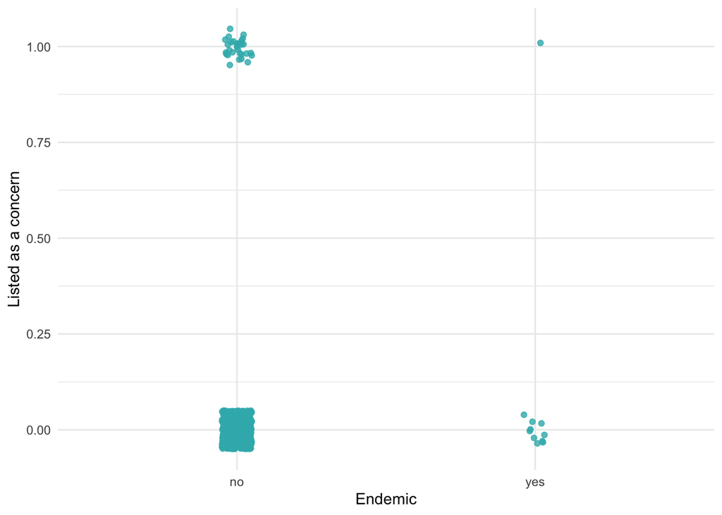

```r
# Plot endemism vs is of concern
gg_end <- ggplot(data = tidy_fish_data, aes(x = is_endemic, y = is_of_concern)) +
  geom_jitter(width = 0.05, height = 0.05, alpha = 0.8, col = "#38b6ba") +
  labs(x = "Endemic", y = "Listed as a concern") +
  theme_minimal()
gg_end
```

```r
# Run a t.test
end_test <- t.test(is_of_concern ~ is_endemic, data = tidy_fish_data)

# Log regression of endemism -- does this even make sense to do?
mod_end <- glm(is_of_concern ~ is_endemic,
                  data = tidy_fish_data,
                  family = "binomial")
summary(mod_end)
```

```
##
## Call:
## glm(formula = is_of_concern ~ is_endemic, family = "binomial",
##     data = tidy_fish_data)
##
## Deviance Residuals:
##     Min       1Q   Median       3Q      Max
## -0.4366  -0.3154  -0.3154  -0.3154   2.4600
##
## Coefficients:
##               Estimate Std. Error z value Pr(>|z|)
## (Intercept)    -2.9762     0.1841 -16.165   <2e-16 ***
## is_endemicyes   0.6736     1.0648   0.633    0.527
## ---
## Signif. codes:  0 '***' 0.001 '**' 0.01 '*' 0.05 '.' 0.1 ' ' 1
##
## (Dispersion parameter for binomial family taken to be 1)
##
##     Null deviance: 255.12  on 649  degrees of freedom
## Residual deviance: 254.78  on 648  degrees of freedom
## AIC: 258.78
##
## Number of Fisher Scoring iterations: 5
```

```r
# Add endemism to the original length model
len_end_mod <- glm(is_of_concern ~ length_cm + is_endemic,
                    data = tidy_fish_data,
                    family = "binomial")
summary(len_end_mod)
```

```
##
## Call:
## glm(formula = is_of_concern ~ length_cm + is_endemic, family = "binomial",
##     data = tidy_fish_data)
##
## Deviance Residuals:
##     Min       1Q   Median       3Q      Max
## -2.9409  -0.2005  -0.1741  -0.1614   2.9268
##
## Coefficients:
##                Estimate Std. Error z value Pr(>|z|)
## (Intercept)   -4.455603   0.341728 -13.038  < 2e-16 ***
## length_cm      0.010958   0.001403   7.812 5.61e-15 ***
## is_endemicyes  1.982199   1.098604   1.804   0.0712 .
## ---
## Signif. codes:  0 '***' 0.001 '**' 0.01 '*' 0.05 '.' 0.1 ' ' 1
##
## (Dispersion parameter for binomial family taken to be 1)
##
##     Null deviance: 255.12  on 649  degrees of freedom
## Residual deviance: 160.20  on 647  degrees of freedom
## AIC: 166.2
##
## Number of Fisher Scoring iterations: 6
```

```r
print(paste0("Fish that are endemic see their odds of being threatened increase by a factor of ", round(len_end_mod$coefficients[3], 2), " after controlling for length"))
```

```
## [1] "Fish that are endemic see their odds of being threatened increase by a factor of 1.98 after controlling for length"
```

```r
# Create confusion matrix to see how well the model performed
length_end_plus <- augment(len_end_mod, type.predict = "response") %>%
  mutate(threatened_hat = round(.fitted)) %>%
  select(is_of_concern, length_cm, is_endemic, .fitted, threatened_hat)
l_e_tab <- length_end_plus %>%
  select(is_of_concern, threatened_hat) %>%
  table()
l_e_tab # Adding endemism did nothing
```

```
##              threatened_hat
## is_of_concern   0   1
##             0 613   5
##             1  20  12
```

### One big model (even though 2/3 do not appear to be significant at all)

$$\operatorname{logit}(p)=\log
\left(\frac{p}{1-p}\right)=\beta_0+\beta_1 (Length) + \beta_2 (Reef) +
\beta_3 (Endemic) +\varepsilon$$

```r
mod <- glm(is_of_concern ~ length_cm + reef_associated + is_endemic,
           data = tidy_fish_data,
           family = "binomial")
summary(mod)
```

```
##
## Call:
## glm(formula = is_of_concern ~ length_cm + reef_associated + is_endemic,
##     family = "binomial", data = tidy_fish_data)
##
## Deviance Residuals:
##     Min       1Q   Median       3Q      Max
## -2.9445  -0.2018  -0.1734  -0.1619   2.9350
##
## Coefficients:
##                     Estimate Std. Error z value Pr(>|z|)
## (Intercept)        -4.431385   0.412313 -10.748  < 2e-16 ***
## length_cm           0.010941   0.001411   7.755 8.83e-15 ***
## reef_associatedyes -0.048016   0.463741  -0.104   0.9175
## is_endemicyes       1.989182   1.100687   1.807   0.0707 .
## ---
## Signif. codes:  0 '***' 0.001 '**' 0.01 '*' 0.05 '.' 0.1 ' ' 1
##
## (Dispersion parameter for binomial family taken to be 1)
##
##     Null deviance: 255.12  on 649  degrees of freedom
## Residual deviance: 160.19  on 646  degrees of freedom
## AIC: 168.19
##
## Number of Fisher Scoring iterations: 6
```

```r
# Pull out all coefficients
b0 <- mod$coefficients[1] #Intercept
b1 <- mod$coefficients[2] #Length
b2 <- mod$coefficients[3] #Reef Associated
b3 <- mod$coefficients[4] #Endemic
```

**Lets say I just through all of these together before my earlier analyses, how do I interpret my coefficients, and how do I determine significance of each part of my model?**

### Use the model

**In an ideal world, I would have a great model (not the case, but I’m rolling with it for practice). I attempt below to predict probability of threatened/not threatened – but is this done correctly?**

```r
# Write a function for testing probabilities
threat_prob <- function(b0, b1, b2, b3, len, reef, end) {
  equ <- b0 * b1 * len * b2 * reef * b3 * end # Right side of equation
  prob <- (exp(equ)) / (1 + exp(equ)) # Pulled form lecture slides
  print(prob)
}
# Test
threat_prob(b0, b1, b2, b3, 700, 1, 1)
```

```
## (Intercept)
##   0.9623749
```

```r
threat_prob(b0, b1, b2, b3, 20, 1, 1)
```

```
## (Intercept)
##   0.5231387
```

```r
threat_prob(b0, b1, b2, b3, 450, 1, 1)
```

```
## (Intercept)
##   0.8893355
```

**I’m surprised a length of 20 cm is reporting a probability of 0.52 – this seems too high, making me suspicious that something here is wrong**